# Data 624 - Project 1

Paul Britton

2020-03-29

# Project 1

The rpubs version of this work can be found[here](https://rpubs.com/plb_lttfer/591649), and source/data can be found on github [here](https://github.com/plb2018/DATA624/tree/master/project1).

## Description

This project consists of 3 parts - two required and one bonus and is worth 15% of your grade. The project is due at 11:59 PM on Sunday March 31. I will accept late submissions with a penalty until the meetup after that when we review some projects.

```r
rm(list = ls())

library(knitr)
library(ggplot2)
library(tidyr)
library(dplyr)
library(tseries)
library(forecast)
library(lubridate)
library(tidyverse)
```

## Load Data

Load all the data for all 3 parts from github in the interest of reproducibility.

```r
temp_file <- tempfile(fileext = ".xlsx")

download.file(url = "https://github.com/plb2018/DATA624/raw/master/project1/ATM624Data.xlsx?raw=true",
              destfile = temp_file,
              mode = "wb",
              quiet = TRUE)

ATM <- readxl::read_excel(temp_file,skip=0,col_types = c("date","text","numeric"))


download.file(url = "https://github.com/plb2018/DATA624/raw/master/project1/ResidentialCustomerForecastLoad-624.xlsx?raw=true",
              destfile = temp_file,
              mode = "wb",
              quiet = TRUE)

power <- readxl::read_excel(temp_file,skip=0,col_types = c("numeric","text","numeric"))




download.file(url = "https://github.com/plb2018/DATA624/raw/master/project1/Waterflow_Pipe1.xlsx?raw=true",
              destfile = temp_file,
              mode = "wb",
              quiet = TRUE)

water1 <- readxl::read_excel(temp_file,skip=0,col_types = c("date","numeric"))

download.file(url = "https://github.com/plb2018/DATA624/raw/master/project1/Waterflow_Pipe2.xlsx?raw=true",
              destfile = temp_file,
              mode = "wb",
              quiet = TRUE)

water2 <- readxl::read_excel(temp_file,skip=0,col_types = c("date","numeric"))
```

## Part A – ATM Forecast

In part A, I want you to forecast how much cash is taken out of 4 different ATM machines for May 2010. The data is given in a single file. The variable ‘Cash’ is provided in hundreds of dollars, other than that it is straight forward. I am being somewhat ambiguous on purpose to make this have a little more business feeling. Explain and demonstrate your process, techniques used and not used, and your actual forecast. I am giving you data via an excel file, please provide your written report on your findings, visuals, discussion and your R code via an RPubs link along with the actual.rmd file Also please submit the forecast which you will put in an Excel readable file.

First we’ll inspect the data to see if we can gain any intuition about what we are working with.

### Inspect the Data

We find a few missing values * 3 cases where we have no Cash values for ATM1 and 2 cases for ATM2, which we will impute after further investigation * The entire month of may is missing as this is what we are asked to forcast.

```r
ATM[!complete.cases(ATM),]
```

| DATE | ATM | Cash |
| --- | --- | --- |
| 2009-06-13 | ATM1 | NA |
| 2009-06-16 | ATM1 | NA |
| 2009-06-18 | ATM2 | NA |
| 2009-06-22 | ATM1 | NA |
| 2009-06-24 | ATM2 | NA |
| 2010-05-01 | NA | NA |
| 2010-05-02 | NA | NA |
| 2010-05-03 | NA | NA |
| 2010-05-04 | NA | NA |
| 2010-05-05 | NA | NA |

[output cut: 9 more lines]

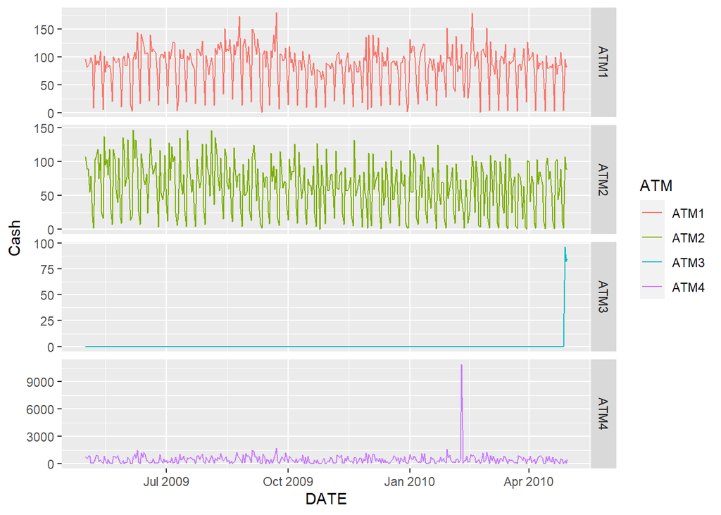

```r
p <- ggplot(ATM[complete.cases(ATM),],aes(x=DATE,y=Cash,color=ATM))+
  geom_line()

p + facet_grid(rows = vars(ATM),scales="free")
```

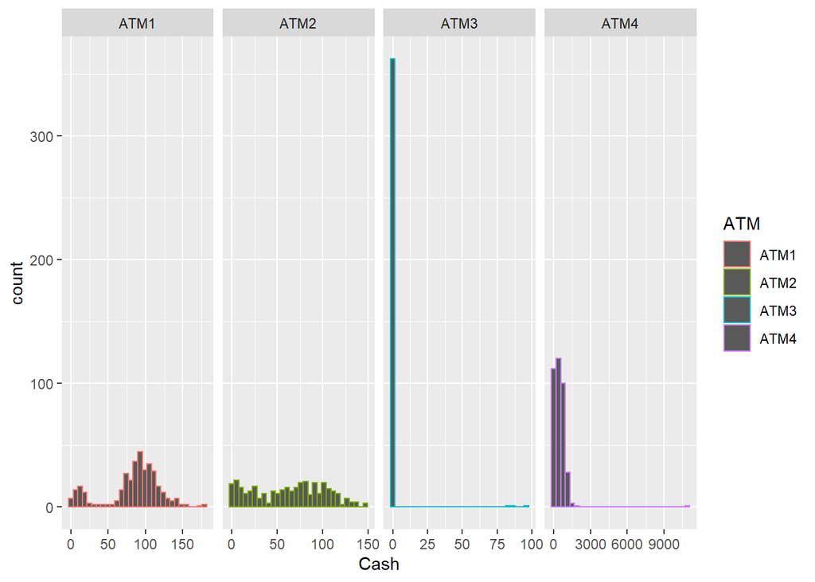

```r
p <- ggplot(ATM[complete.cases(ATM),],aes(x=Cash,color=ATM))+
  geom_histogram()

p + facet_grid(cols = vars(ATM),scales="free")
```

From plotting the data, we can see that ATM1 and ATM2 look roughly similar in terms of withdrawls and cyclicality / seasonality. ATM3 appears as though it has just come “on-line” and thus has almost no history.

ATM4 has several oddities. First, we see a monstrous outlier value of 10919.76. Given that these values are in 100s, the outlier equates to > $1 Million, which is substantially more than ATMs typically hold - quick googling suggests that most ATMs carry about 10K and the max is around 200K - so something is wrong here. Common sense (based on context) dictates that this outlier is likely an error. I also note that the data from ATM4 are not integers which is odd as ATMs only dispense bills. I wonder whether this data is from an ATM that dispenses non-USD, yet is reported in USD or something similar…

### Check for Seasonality / Cyclicality

We will eliminate the massive outlier from ATM4, and examine the data for any seasonal / cyclical patterns

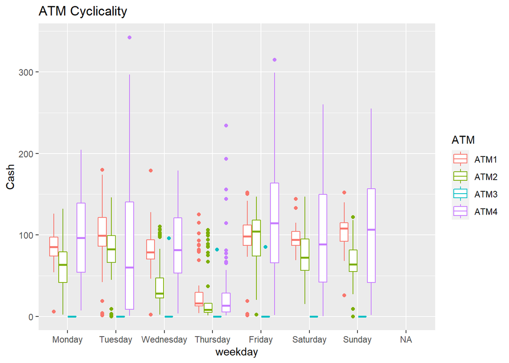

```r
#drop the outlier
ATM2 = ATM[ATM$Cash < 9500,]

#add a weekday col
ATM2$weekday <- factor(weekdays(as.Date(ATM2$DATE)))

#reorder levels
ATM2$weekday <- ordered(ATM2$weekday,levels = c("Monday","Tuesday","Wednesday","Thursday","Friday","Saturday","Sunday"))

#drop nas for now
ATM2 <- ATM2[complete.cases(ATM2),]

#rescale AMT 4, for plotting
ATM2$Cash[ATM2$ATM == "ATM4"] <- ATM2$Cash[ATM2$ATM == "ATM4"]/5

ggplot(ATM2[complete.cases(ATM),],aes(x=weekday,y=Cash,color=ATM))+
  geom_boxplot()+
  ggtitle("ATM Cyclicality")
```

From the above plots we can see that there is a weekly cycle where Thursday appears to have dramatically lower withdrawls than all other days. Note that in this plot, ATM4 has been re-scaled to make the visualization easier on the eyes.

### Impute Missing Values

Given that the day-of-week appears to be important, we will use this data when imputing missing values. We will impute using the median values for the week-day of eash missing data-point. As can be seen below, a missing “Thursday” probably warrants a different value than a missing “Saturday”

```r
medians.by.weekday <- ATM2 %>%
    group_by(weekday,ATM) %>%
    summarise_at(vars(-DATE), funs(median(., na.rm=TRUE)))
```

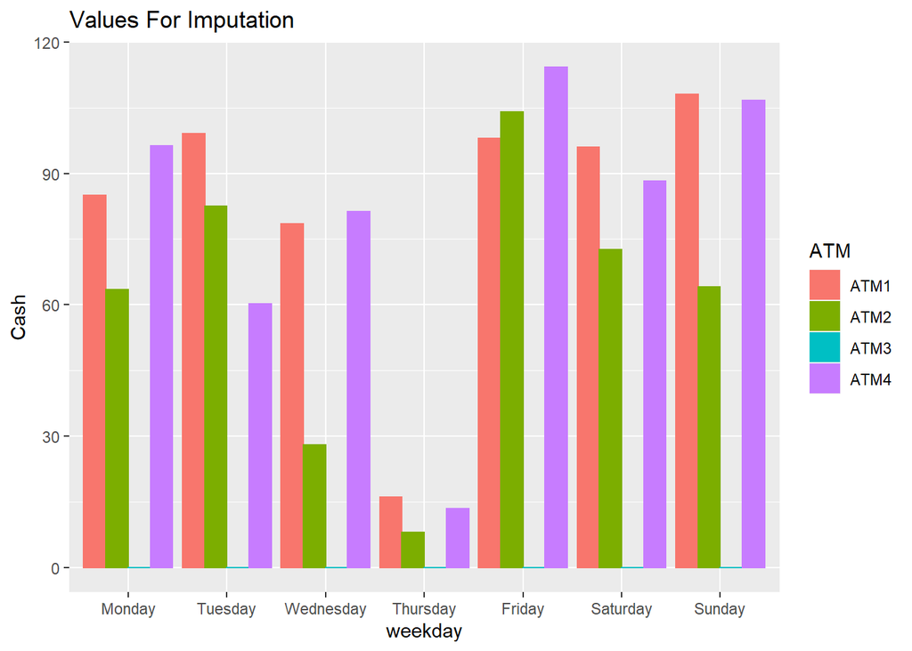

```r
ggplot(medians.by.weekday,aes(x=weekday,y=Cash,color=ATM,group=ATM,fill=ATM))+
  geom_bar(stat="identity",position="dodge")+
  ggtitle("Values For Imputation")
```

Given that there are so few missing values, we’ll perform the imputation manually. If there were substantially more, or expected to be substantially more in the future, we would obviously build a more efficient process to handle this.

```r
ATM$weekday <- factor(weekdays(as.Date(ATM$DATE)))

missing.values <- head(ATM[is.na(ATM$Cash) ,],5)

kable(missing.values,caption = "The Missing Values with Weekdays")
```

The Missing Values with Weekdays

| DATE | ATM | Cash | weekday |
| --- | --- | --- | --- |
| 2009-06-13 | ATM1 | NA | Saturday |
| 2009-06-16 | ATM1 | NA | Tuesday |
| 2009-06-18 | ATM2 | NA | Thursday |
| 2009-06-22 | ATM1 | NA | Monday |
| 2009-06-24 | ATM2 | NA | Wednesday |

```r
#grab index for missing values
missing.idx <- head(which(is.na(ATM$Cash)),5)

#manually replace each one
ATM$Cash[missing.idx[1]]<- medians.by.weekday$Cash[(medians.by.weekday$weekday=="Saturday") & (medians.by.weekday$ATM == "ATM1")]

ATM$Cash[missing.idx[2]] <- medians.by.weekday$Cash[(medians.by.weekday$weekday=="Tuesday") & (medians.by.weekday$ATM == "ATM1")]

ATM$Cash[missing.idx[3]] <- medians.by.weekday$Cash[(medians.by.weekday$weekday=="Thursday") & (medians.by.weekday$ATM == "ATM2")]


ATM$Cash[missing.idx[4]] <- medians.by.weekday$Cash[(medians.by.weekday$weekday=="Monday") & (medians.by.weekday$ATM == "ATM1")]

ATM$Cash[missing.idx[5]] <- medians.by.weekday$Cash[(medians.by.weekday$weekday=="Wednesday") & (medians.by.weekday$ATM == "ATM2")]


ATM$Cash[ATM$Cash > 9000]  <- medians.by.weekday$Cash[(medians.by.weekday$weekday=="Tuesday") & (medians.by.weekday$ATM == "ATM4")]

#check updated values
kable( ATM[missing.idx,],caption = "The Imputed Values")
```

The Imputed Values

| DATE | ATM | Cash | weekday |
| --- | --- | --- | --- |
| 2009-06-13 | ATM1 | 96 | Saturday |
| 2009-06-16 | ATM1 | 99 | Tuesday |
| 2009-06-18 | ATM2 | 8 | Thursday |
| 2009-06-22 | ATM1 | 85 | Monday |
| 2009-06-24 | ATM2 | 28 | Wednesday |

### Split the data into 4 Timeseries, Build Models

The characteristics of the ATMs seem distinct enough that they could be modelled as 4 separate processes. Given more time, I would likley try to tackle this as a more generalized “N-in, 1 out” so that i could make use of ALL the ATM data for each prediction, but i have not done that here.

#### ATM1

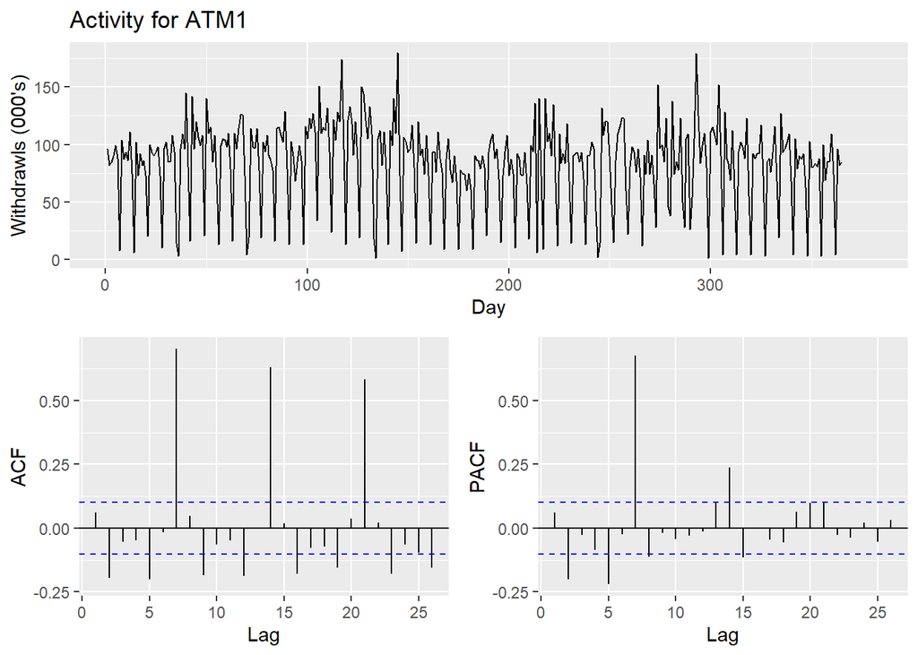

```r
ATM1 <- ATM[ATM$ATM == "ATM1",]

ATM1 <- ts(ATM1[c("Cash")])

ggtsdisplay(ATM1, points = FALSE,
            main = "Activity for ATM1",
            xlab = "Day",
            ylab = "Withdrawls (000's)")
```

The weekly cycle is quite apparent in all 3 of the above plots and the relevant period is 7-days (i.e. thursdays appear to show a major slowdown in activity). We’ll difference using a lag of 7-periods and rub some stationarity tests

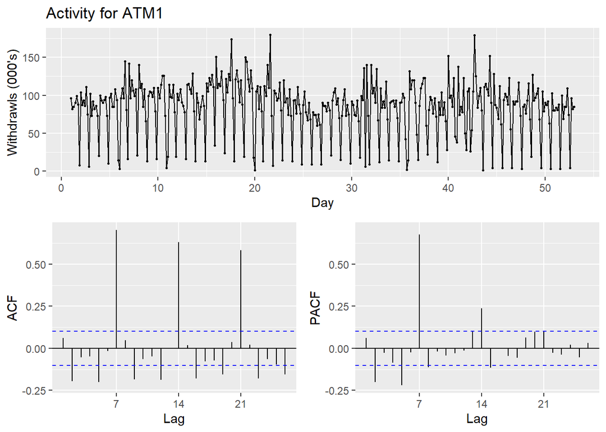

```r
ATM1 <- ATM[ATM$ATM == "ATM1",]

ATM1 <- ATM1[complete.cases(ATM1),]

ATM1 <- ts(ATM1[c("Cash")],frequency = 7)

ggtsdisplay(ATM1,
            main = "Activity for ATM1",
            xlab = "Day",
            ylab = "Withdrawls (000's)")
```

```r
Box.test(diff(ATM1,lag=7), type = "Ljung-Box")
```

```
##
##  Box-Ljung test
##
## data:  diff(ATM1, lag = 7)
## X-squared = 9.8085, df = 1, p-value = 0.001737
```

```r
kpss.test(diff(ATM1,lag=7))
```

```
##
##  KPSS Test for Level Stationarity
##
## data:  diff(ATM1, lag = 7)
## KPSS Level = 0.021721, Truncation lag parameter = 5, p-value = 0.1
```

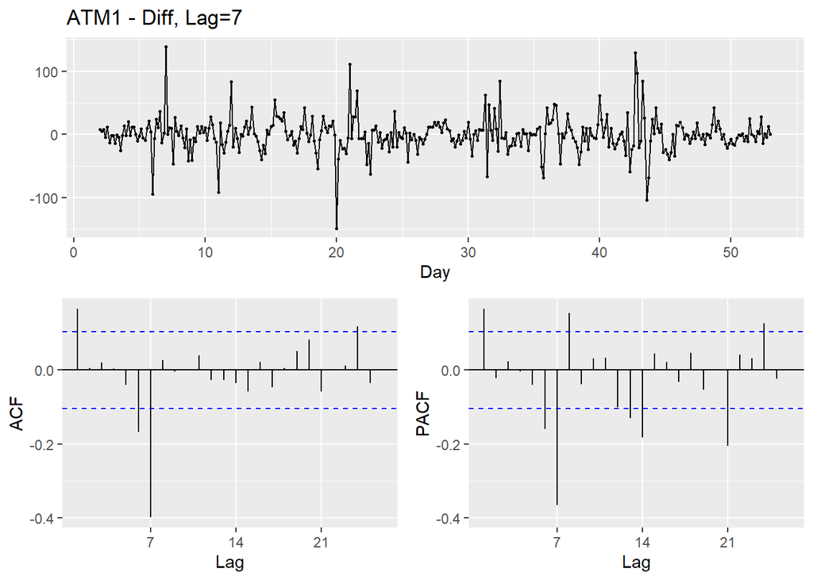

```r
ggtsdisplay(diff(ATM1,lag=7),
            main = "ATM1 - Diff, Lag=7",
            xlab = "Day",
            ylab = "")
```

Based on kpss output the series appears stationary so we will move onto the modelling part.

The Spike at lag=1 suggests an MA component and the large spike at lag=7 is consistent with the seasonal component we’ve already discussed. The variability looks reasonably stable but we’ll run a BoxCox anyway just to be sure.

We use auto.arima to search a model-space and return an appropriate model:

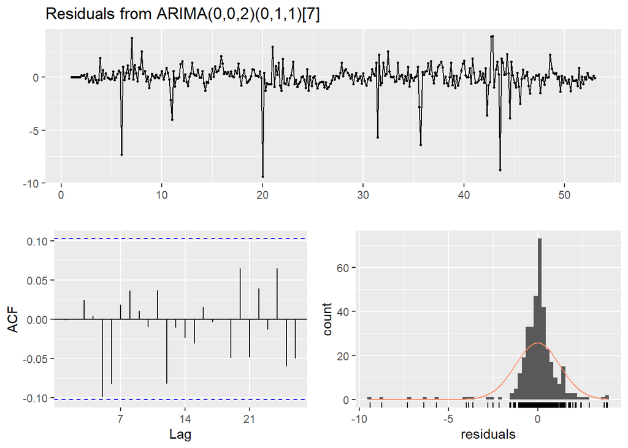

```
##
##  Ljung-Box test
##
## data:  Residuals from ARIMA(0,0,2)(0,1,1)[7]
## Q* = 10.52, df = 11, p-value = 0.4843
##
## Model df: 3.   Total lags used: 14
```

```r
lambda = BoxCox.lambda(ATM1)
ATM1.arima <- auto.arima(ATM1,approximation = F,lambda = lambda)

checkresiduals(ATM1.arima)
```

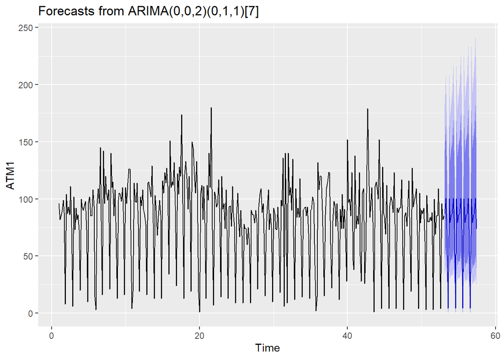

```r
ATM1.arima %>% forecast(h=31) %>% autoplot()
```

```r
kpss.test(resid(ATM1.arima))
```

```
##
##  KPSS Test for Level Stationarity
##
## data:  resid(ATM1.arima)
## KPSS Level = 0.094343, Truncation lag parameter = 5, p-value = 0.1
```

The model looks reasonably good with the residuals approximately normally distributed (albiet with some left skew) and the ACF values all in-bounds. The forcast plot also looks reasonable to me.

#### ATM2

Given the similarity between ATM1 & ATM2, we’ll follow more-or-less the same process.

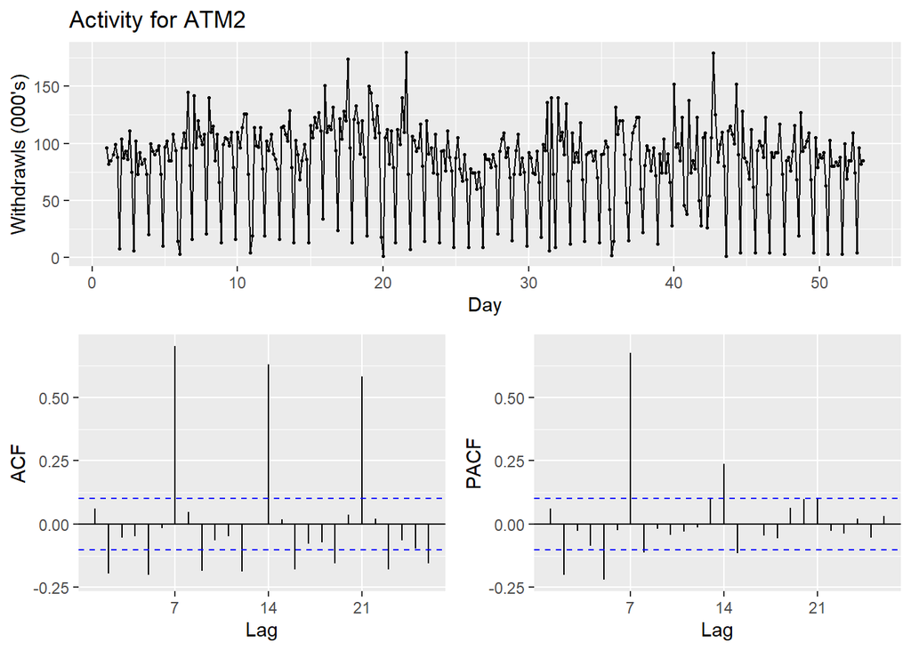

```r
ATM2 <- ATM[ATM$ATM == "ATM2",]


ATM2 <- ATM2[complete.cases(ATM2),]

ATM2 <- ts(ATM2[c("Cash")],frequency = 7)

ggtsdisplay(ATM1,
            main = "Activity for ATM2",
            xlab = "Day",
            ylab = "Withdrawls (000's)")
```

```r
Box.test(diff(ATM1,lag=7), type = "Ljung-Box")
```

```
##
##  Box-Ljung test
##
## data:  diff(ATM1, lag = 7)
## X-squared = 9.8085, df = 1, p-value = 0.001737
```

```r
kpss.test(diff(ATM1,lag=7))
```

```
##
##  KPSS Test for Level Stationarity
##
## data:  diff(ATM1, lag = 7)
## KPSS Level = 0.021721, Truncation lag parameter = 5, p-value = 0.1
```

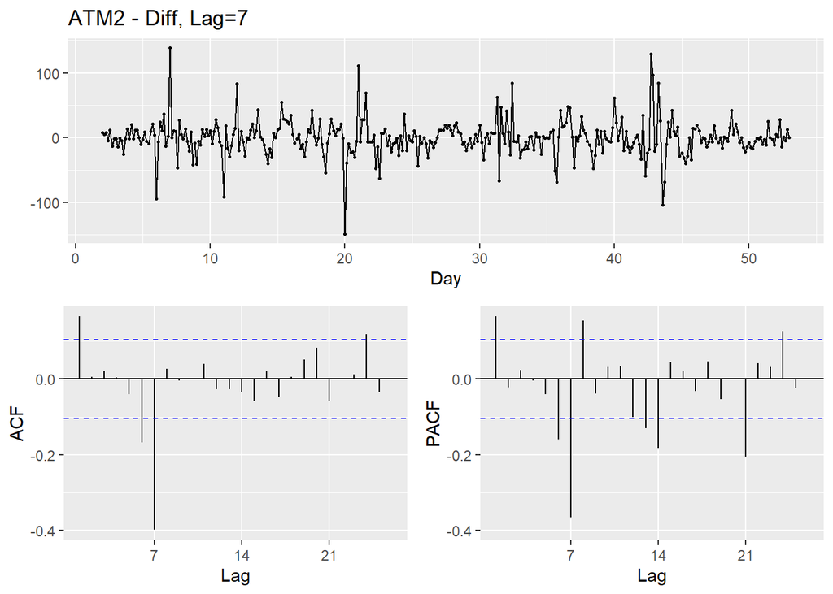

```r
ggtsdisplay(diff(ATM1,lag=7),
            main = "ATM2 - Diff, Lag=7",
            xlab = "Day",
            ylab = "")
```

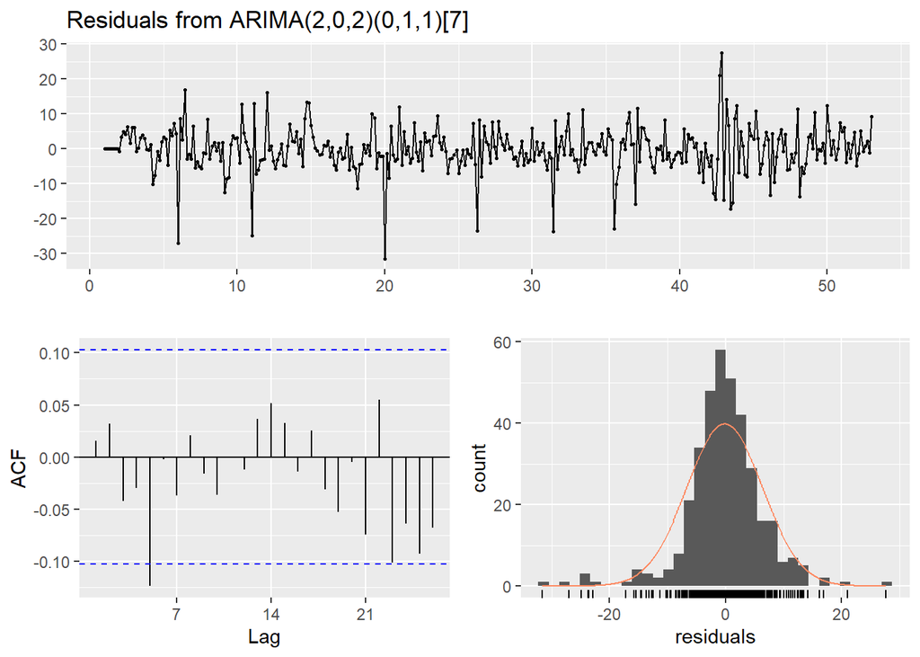

```
##
##  Ljung-Box test
##
## data:  Residuals from ARIMA(2,0,2)(0,1,1)[7]
## Q* = 9.987, df = 9, p-value = 0.3515
##
## Model df: 5.   Total lags used: 14
```

```r
lambda = BoxCox.lambda(ATM2)
ATM2.arima <- auto.arima(ATM2,approximation = F,lambda = lambda)

checkresiduals(ATM2.arima)
```

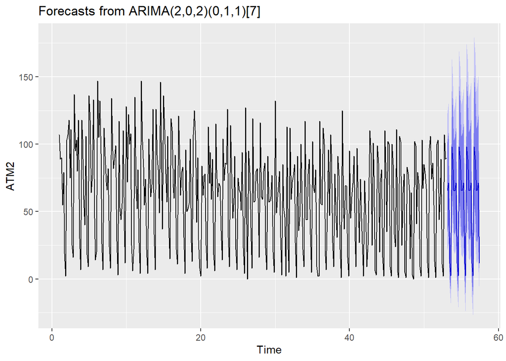

```r
ATM2.arima %>% forecast(h=31) %>% autoplot()
```

```r
kpss.test(resid(ATM2.arima))
```

```
##
##  KPSS Test for Level Stationarity
##
## data:  resid(ATM2.arima)
## KPSS Level = 0.071598, Truncation lag parameter = 5, p-value = 0.1
```

The model for ATM2 looks reasonable as well - resituals appear to be random, the ACF is more-or-less entirely in-bounds and the distribution of residuals is normal. The model parameters are slightly different from those of ATM1

#### ATM3

ATM 3 poses a bit of a tricky problem. We have almost no data and thus nothing to model. However, the limited data that we DO have appears reasonably similar to that of ATM1 and ATM2 so rather than having no forecast or using a fixed value or similar, we will use the mean of ATM1 and ATM2. I feel this is appropriate because we know ATM3 is, in fact, an ATM (which tells us a lot!) and that the limited data we have looks similar to a few other ATMs we know something about.

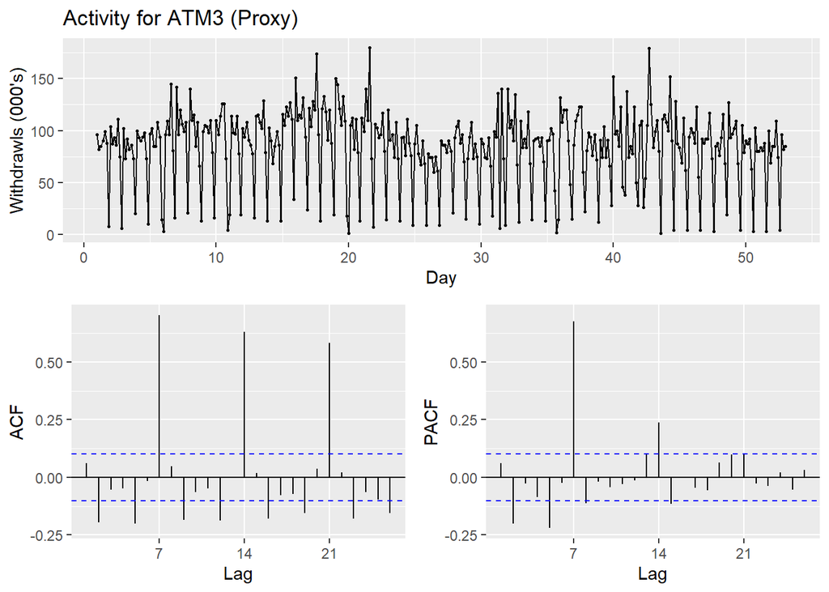

```r
ATM3 <- (ATM1 + ATM2) /2

ggtsdisplay(ATM1,
            main = "Activity for ATM3 (Proxy)",
            xlab = "Day",
            ylab = "Withdrawls (000's)")
```

```r
Box.test(diff(ATM1,lag=7), type = "Ljung-Box")
```

```
##
##  Box-Ljung test
##
## data:  diff(ATM1, lag = 7)
## X-squared = 9.8085, df = 1, p-value = 0.001737
```

```r
kpss.test(diff(ATM1,lag=7))
```

```
##
##  KPSS Test for Level Stationarity
##
## data:  diff(ATM1, lag = 7)
## KPSS Level = 0.021721, Truncation lag parameter = 5, p-value = 0.1
```

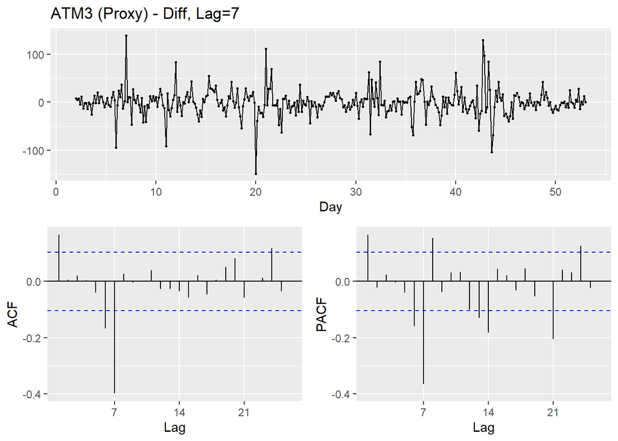

```r
ggtsdisplay(diff(ATM1,lag=7),
            main = "ATM3 (Proxy) - Diff, Lag=7",
            xlab = "Day",
            ylab = "")
```

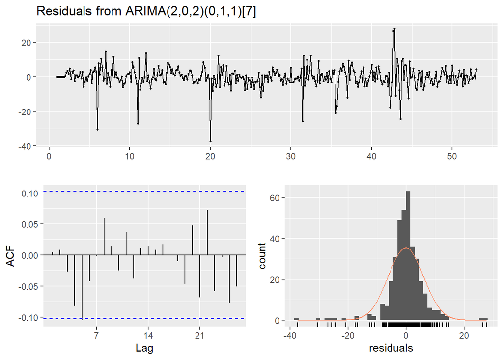

```
##
##  Ljung-Box test
##
## data:  Residuals from ARIMA(2,0,2)(0,1,1)[7]
## Q* = 10.476, df = 9, p-value = 0.3134
##
## Model df: 5.   Total lags used: 14
```

```r
lambda = BoxCox.lambda(ATM3)
ATM3.arima <- auto.arima(ATM3,approximation = F,lambda = lambda)

checkresiduals(ATM3.arima)
```

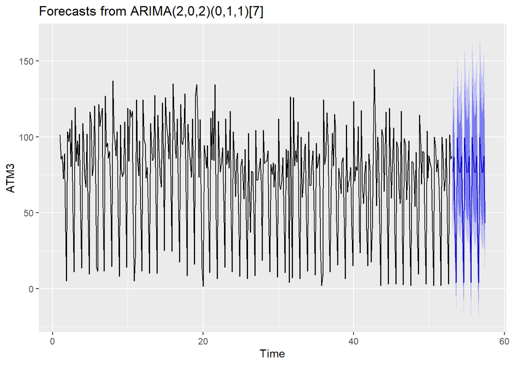

```r
ATM3.arima %>% forecast(h=31) %>% autoplot()
```

```r
kpss.test(resid(ATM3.arima))
```

```
##
##  KPSS Test for Level Stationarity
##
## data:  resid(ATM3.arima)
## KPSS Level = 0.096755, Truncation lag parameter = 5, p-value = 0.1
```